# `RHugin` Install Instructions for Linux

Last updated by Kjell Konis on 2017-02-06.

These instructions are a little sparse compared to the instrcutions for Windows and Mac OS X. There are many flavors of Linux so it is not really possible to provide a one-size-fits-all set of instrctions. Please feel free to contact me if you need any help.

### Preliminaries

The `RHugin` package provides an R API for the HUGIN Decision Engine (HDE): both the HDE and R must be installed on the computer in order for the `RHugin` package to function. Since `RHugin` is distributed as a source package, the tools (compilers, etc.) needed to install R source packages must be installed on your computer.

#### Install HUGIN and the HUGIN Decision Engine (HDE)

The HUGIN Decision Engine is commercial software available from HUGIN EXPERT.

> http://www.hugin.com

The products *HUGIN Developer* (commercial use) and *HUGIN Researcher* (academic use) include the HUGIN Decision Engine. The HDE is also included with the free demo *HUGIN Lite* (the only permitted use of the free demo is to evaluate HUGIN). These instructions assume that the HDE you want to link `RHugin` against is installed in `/usr/local/hugin`.

### RHugin Package Depedencies

The `RHugin` package has dependencies on the `graph` and `Rgraphviz` packages. These packages are part of Bioconductor and can be installed by running the following two R commands.

```r
source("https://bioconductor.org/biocLite.R")
biocLite(c("graph", "Rgraphviz"))
```

### Install the RHugin Package

First, set the `HUGINHOME` environment variable so that `RHugin` can find the HUGIN Decision Engine (HDE). The value (i.e., the “/usr/local/hugin” in the code below) should be the full path to the HDE folder that you installed in the *Preliminaries* section.

```r
Sys.setenv(HUGINHOME = "/usr/local/hugin")
```

Then, install the `RHugin` package from RHugin’s R-Forge repository with the following R command.

```r
install.packages("RHugin", repos = "http://rhugin.r-forge.r-project.org",
                 type = "source", INSTALL_opts="--no-multiarch")
```

### Quick Test

To check that everything went as planned run the following code to plot one of HUGIN’s example networks.

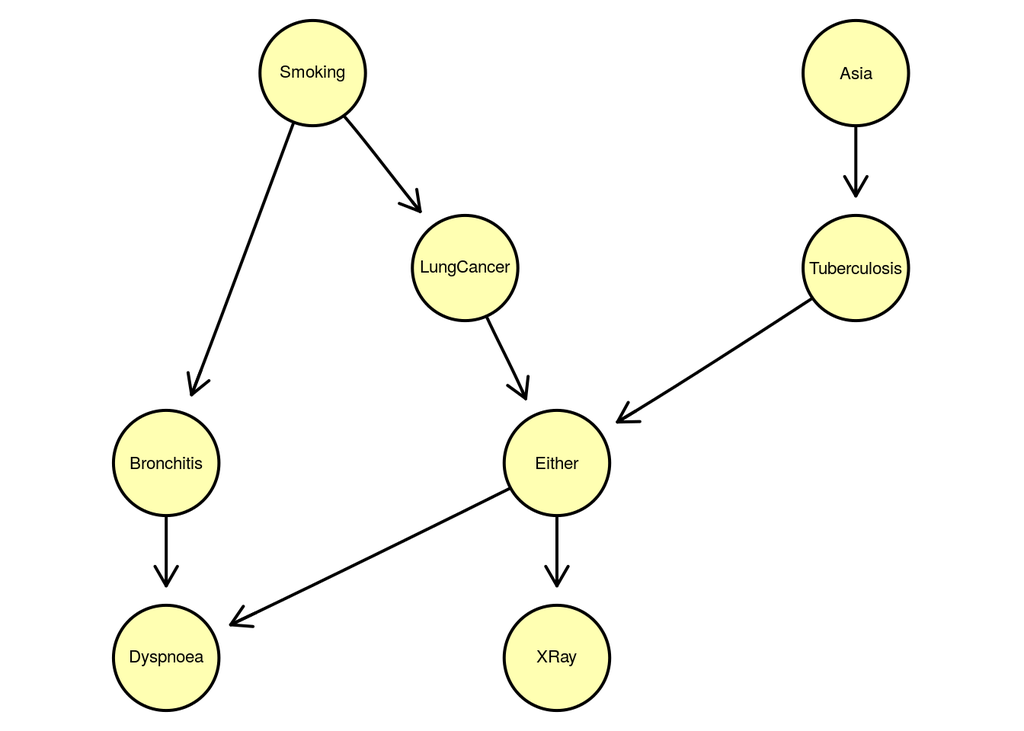

```r
library(RHugin)
demo("asia", echo = FALSE)
plot(asia)
```

Happy HUGINing with RHugin!

Copyright 2017 Kjell Konis